# Recommended Resources

The following is a list of open-source and private resources to improve your data science and machine learning tradecraft. By no means it is an all-inclusive roster, instead some of the ones I have used before.

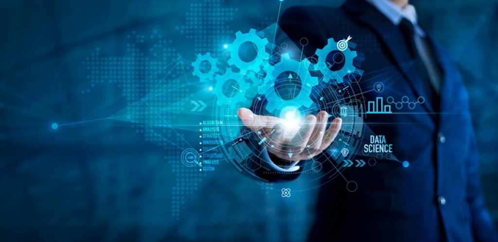

### Web Sites

- [The Algorithms](https://the-algorithms.com)
- [Data Science Resource Hub - SAS](https://www.sas.com/en_us/training/academy-data-science/data-science-resources.html#data-scientist-learning-journey)
- [Data Science Central](https://www.datasciencecentral.com)
- [Data, AI & Machine Learning](https://sloanreview.mit.edu/topic/data-ai-machine-learning/)
- [Storytelling with Data](https://www.storytellingwithdata.com/chart-guide)

### Courses

- Introduction to Data Science | edx IBM
- [The Data Scientist’s Toolbox](https://www.coursera.org/learn/data-scientists-tools#modules)
- [Analyze Data with Pandas](https://www.codecademy.com/learn/paths/analyze-data-with-python)
- Professional Certificate in Data Science | edx Harvard
- Applied Data Science Program: Leveraging AI for Effective Decision-Making | MiT
- [Deep Learning | Deeplizard](https://deeplizard.com/courses)
- [Deep Learning Toolbox | MathWorks](https://www.mathworks.com/help/deeplearning/examples.html?s_tid=ans_recom_nba-get)

### Projects & Books

- [Big Book of R](https://www.bigbookofr.com)
- [Data Science on the GCP](https://www.oreilly.com/library/view/data-science-on/9781491974551/)
- [100+ Python projects](https://thecleverprogrammer.com/2021/01/14/python-projects-with-source-code/)
- [R Books Collection](https://www.rstudio.com/resources/books/)
- [40+ Modern ML Tutorials](https://www.datasciencecentral.com/40-tutorials-covering-all-aspects-of-machine-learning/)

### Visualization Package/Libraries

- [matplotlib](https://matplotlib.org/stable/)
- [ggplot2](https://exts.ggplot2.tidyverse.org/gallery/)
- [seaborn](https://seaborn.pydata.org)
- [Google Charts](https://developers.google.com/chart/interactive/docs/gallery)
- [Grafana](https://grafana.com/grafana/)
- [Datawrapper](https://www.datawrapper.de)
- [Visual Cinnamon](https://www.visualcinnamon.com/portfolio/)

### BI Tools & Platforms

- [KNIME](https://www.knime.com/knime-analytics-platform)
- [SAS Enterprise Miner](https://www.sas.com/en_us/software/enterprise-miner.html)
- [IBM Cognos Analytics](https://www.ibm.com/products/cognos-analytics)
- [Splunk MLTK](https://splunkbase.splunk.com/app/2890)
- [Shiny](https://shiny.posit.co/?_gl=1*ndp1ah*_ga*MTMyMDE5NzEyMi4xNjg1MDMwNzUx*_ga_2C0WZ1JHG0*MTY4NTE1Njk4My40LjEuMTY4NTE1NzMxNi4wLjAuMA..)
- [Mode](https://mode.com/platform)
- [OSF](https://osf.io)
- [Quarto](https://quarto.org)
- [RStudio](https://posit.co/products/open-source/rstudio/)
- [Anaconda](https://www.anaconda.com/products/data-science-ai-workbench)
- [Orange](https://orangedatamining.com)
- [Spyder](https://www.spyder-ide.org)
- [Jupyter](https://jupyter.org)

### Community

- [Data Science Hangout](https://posit.co/data-science-hangout/) by Posit
- [The Data Canteen](https://vetsindatascience.com/the-data-canteen) by Ted Hallum
- [Data Humans Podcast](https://libbyheeren.com/podcast.html) by Libby Heeren
- [Data Science Leaders Podcast](https://domino.ai/data-science-leaders-podcast) by Kjell Carlsson
- [Data Skeptic Podcast](https://dataskeptic.com) by Kyle Polich
- [Super Data Science Podcast](https://www.superdatascience.com/podcast/) by Jon Krohn